# WRT - AutoTrader - Technical Assessment - Modelling

Notebook for modelling the cleaned (deduplicated, missing value imputed, columns dropped, anomalies removed) data to predict the price variable.

# Setup

```python
# load libraries
import warnings
import pandas as pd
import seaborn as sns
import matplotlib.pyplot as plt
import numpy as np
from scipy import stats
from sklearn.model_selection import train_test_split
from sklearn.linear_model import LinearRegression
from sklearn.ensemble import RandomForestRegressor
from sklearn.metrics import (
    mean_absolute_error,
    mean_squared_error,
    r2_score,
    mean_absolute_percentage_error,
    root_mean_squared_error,
)
from sklearn.preprocessing import StandardScaler
import category_encoders as ce
from tqdm import tqdm
from sklearn.ensemble import GradientBoostingRegressor
from pprint import pprint
from sklearn.model_selection import RandomizedSearchCV

# setup notebook
pd.set_option("display.max_columns", None)

# hide warnings for cleaner outputs
warnings.filterwarnings("ignore")
```

# Load

```python
# load data
directory_path = "/Users/nb1777/Git/autotrader_technical_assessment"
file_path = "price_prediction/price_prediction/data/clean_vehicle_data.csv"
df_in = pd.read_csv("/".join([directory_path, file_path]))
```

```python
df_in.head(10)
```

|  | make | model | body_type | fuel_type | engine_size | transmission | year | mileage | price | colour | area | feature_1 | feature_2 | feature_3 | feature_4 | feature_5 | feature_6 | feature_7 | feature_8 | feature_9 | feature_10 | price_position |
| --- | --- | --- | --- | --- | --- | --- | --- | --- | --- | --- | --- | --- | --- | --- | --- | --- | --- | --- | --- | --- | --- | --- |
| 0 | BMW | X1 | SUV | Petrol | 2.0 | Automatic | 2021.0 | 13434 | 32000 | Blue | BS | 1 | 1 | 1 | 0 | 1 | 1 | 0 | 1 | 1 | 1 | 100.4 |
| 1 | BMW | 2 Series Gran Coupe | Saloon | Petrol | 1.5 | Automatic | 2021.0 | 6347 | 32898 | Blue | G | 1 | 0 | 1 | 0 | 0 | 0 | 1 | 0 | 0 | 0 | 111.3 |
| 2 | BMW | 2 Series Gran Coupe | Saloon | Petrol | 1.5 | Manual | 2021.0 | 10 | 35510 | Blue | PE | 1 | 1 | 1 | 0 | 1 | 0 | 1 | 1 | 0 | 0 | NaN |
| 3 | BMW | 4 Series | Coupe | Diesel Hybrid | 2.0 | Automatic | 2022.0 | 6500 | 37999 | Grey | B | 1 | 1 | 1 | 0 | 1 | 1 | 1 | 0 | 0 | 0 | 102.5 |
| 4 | BMW | 1 Series | Hatchback | Diesel | 2.0 | Manual | 2012.0 | 136952 | 4890 | Black | S | 0 | 0 | 0 | 0 | 0 | 0 | 0 | 0 | 0 | 0 | 99.1 |
| 5 | BMW | 2 Series Gran Tourer | MPV | Diesel | 2.0 | Automatic | 2017.0 | 48690 | 19200 | Silver | PE | 0 | 0 | 0 | 0 | 0 | 1 | 0 | 1 | 0 | 0 | 104.1 |
| 6 | BMW | 2 Series | Coupe | Petrol | 1.5 | Manual | 2018.0 | 14000 | 19990 | Grey | BN | 1 | 1 | 1 | 0 | 0 | 1 | 1 | 0 | 1 | 0 | 111.6 |
| 7 | BMW | X4 | SUV | Diesel Hybrid | 2.0 | Automatic | 2021.0 | 14708 | 44990 | Blue | PH | 0 | 0 | 0 | 1 | 1 | 0 | 1 | 0 | 0 | 0 | 102.5 |
| 8 | BMW | 2 Series Active Tourer | MPV | Petrol | 1.5 | Manual | 2018.0 | 29745 | 16000 | Black | WN | 0 | 0 | 1 | 0 | 0 | 0 | 0 | 0 | 0 | 0 | 107.3 |
| 9 | BMW | 7 Series | Saloon | Diesel | 3.0 | Automatic | 2019.0 | 22370 | 37750 | Multicolour | EH | 0 | 0 | 0 | 0 | 0 | 1 | 0 | 0 | 0 | 0 | 91.4 |

```python
# missing values
df_in.isna().sum()
```

```
make                0
model               0
body_type           0
fuel_type           0
engine_size         0
transmission        0
year                0
mileage             0
price               0
colour              0
area                0
feature_1           0
feature_2           0
feature_3           0
feature_4           0
feature_5           0
feature_6           0
feature_7           0
feature_8           0
feature_9           0
feature_10          0
price_position    984
dtype: int64
```

```python
# drop `price_position` - not needed for modelling and contains NaNs
df = df_in.drop(["price_position"], axis=1)
print(df.shape)
```

```
(9522, 21)
```

# Functions

Collection of functions used to streamline the modelling process:

- function to calculate model performance metrics
- function to get feature importance
- function to get and plot model metrics

```python
def get_importance(model, features, model_type):
    """
    calculate feature importance based on the model type

    parameters:
    - model: scikit-learn regression model
        the fitted model to extract importances from
    - features: list
        list of feature names
    - model_type: str
        the type of model (e.g., 'LR' for Linear Regression, 'RF' for Random Forest, 'GB' for Gradient Boosting)

    returns:
    - pd.DataFrame
        a DataFrame containing variable names and their importance values
    """
    if model_type == "LR":
        # for linear regression, use coefficients
        importance = model.coef_
        importances = {"Variable": features, "Importance": importance}

    elif model_type in ["RF", "GB"]:
        # for random forest or gradient boosting, use feature importances
        importance = model.feature_importances_
        importances = {"Variable": features, "Importance": importance}

    else:
        # default case for unsupported models
        return None

    # print out the importance in a formatted table
    print(f"\n{'Variable':<40} {'Importance':<10}")
    print("-" * 50)
    for index, row in pd.DataFrame(importances).iterrows():
        print(f"{row['Variable']:<40}: {row['Importance']:.4f}")

    return importances
```

```python
def evaluate_model(
    model,
    features,
    X_train,
    X_test,
    y_train,
    y_test,
    model_type,
    model_variant,
    model_description,
    print_metrics=True,
    return_importance=True,
):
    """
    evaluate a regression model using various performance metrics

    parameters:
    - model: scikit-learn regression model
        the regression model to be evaluated
    - features: list
        list of feature names
    - X_train: array-like, shape (n_samples, n_features)
        training feature set
    - X_test: array-like, shape (n_samples, n_features)
        testing feature set
    - y_train: array-like, shape (n_samples,)
        training target variable
    - y_test: array-like, shape (n_samples,)
        testing target variable
    - model_type: str
        the type of model (e.g., 'LR' for Linear Regression, 'RF' for Random Forest, 'GB' for Gradient Boosting)
    - model_variant: str
        a variant of the model type (e.g., 'default', 'tuned')
    - model_description: str
        a description of the model variant

    optional parameters:
    - print_metrics: bool, default=True
        if True, prints the calculated metrics
    - return_importance: bool, default=True
        if True, returns feature importances

    returns:
    - metrics: dict
        a dictionary containing the calculated performance metrics
    - importances: pd.DataFrame or None
        a DataFrame containing coefficients or feature importances if applicable, else None
    """

    # fit the model
    model.fit(X_train, y_train)

    # predict using the test data
    y_pred = model.predict(X_test)

    # calculate performance metrics
    metrics = {
        "Model": model_type,
        "Model-Desc": " - ".join([model_type + model_variant, model_description]),
        "MAE": mean_absolute_error(y_test, y_pred),
        "MSE": mean_squared_error(y_test, y_pred),
        "MAPE": mean_absolute_percentage_error(y_test, y_pred)
        * 100,  # MAPE as a percentage
        "R-squared": r2_score(y_test, y_pred),
    }

    # print metrics if print_metrics is True
    if print_metrics:
        print(f"{'Metric':<20} {'Value':<10}")
        print("-" * 30)
        for key, value in metrics.items():
            if "Model" in key:
                print(f"{key:<20}: {value}")
            else:
                print(f"{key:<20}: {value:.4f}")

    # calculate feature importance if return_importance is True
    importances = None
    if return_importance:
        importances = get_importance(model, features, model_type)

    return metrics, importances
```

```python
def generate_plot(df_model_metrics, model_name, export_graph=False):
    """
    generate scatter plots of model metrics over iterations and calculate
    their average and standard deviation

    parameters:
    - df_model_metrics: pd.DataFrame
        dataframe containing model metrics for different iterations
        the dataframe should have metrics as columns and iterations as rows
    - model_name: str
        the name of the model being evaluated (used in the plot title and when printing averages)
    - export_graph: bool, default=False
        if True, saves the plot to a specified file path

    returns:
    - pd.DataFrame
        dataframe containing the model name, metric names, their mean, and standard deviation

    this function creates a subplot for each metric, displaying individual
    metric values for each iteration and includes a horizontal line
    representing the average value of each metric
    """

    # create subplots
    fig, axs = plt.subplots(1, 4, figsize=(16, 6))

    metric_results = []
    i = 0
    print(f"\n{'Metric':<20} {'Mean Value':<10}")
    print("-" * 30)

    # iterate over each metric in the dataframe
    for mtr in df_model_metrics.columns:
        # process only metric columns (skip model name columns)
        if "Model" not in mtr:
            # calculate mean and standard deviation for the metric
            mean_value = df_model_metrics[mtr].mean()
            std_value = df_model_metrics[mtr].std()

            # store metric results in the list
            metric_results.append(
                {
                    "Model": model_name,
                    "Metric": mtr,
                    "Mean": float(mean_value),
                    "Std": float(std_value),
                }
            )

            # print metric mean
            print(f"{mtr:<20}: {mean_value:.3f}")

            # plot scatter plot for the metric values
            axs[i].scatter(
                df_model_metrics.index,
                df_model_metrics[mtr],
                color=sns.color_palette()[i],
            )
            axs[i].axhline(
                y=mean_value, color="black", linestyle="--", label=f"Average {mtr}"
            )
            axs[i].set_title(f"{mtr}")
            axs[i].set_xlabel("Iteration")
            axs[i].set_ylabel(mtr)

            # increment the subplot index
            i += 1

    # set the main title for the entire figure
    plt.suptitle(model_name, fontsize=16)
    plt.tight_layout()

    # export the graph if requested
    if export_graph:
        directory_path = "/Users/nb1777/Git/wrt_at"
        file_path = "vehicle_price_prediction/vehicle_price_prediction/outputs"
        file_name = (
            "model_"
            + model_name.replace(" ", "").replace("-", "_").replace("+", "_").lower()
            + ".png"
        )
        plt.savefig("/".join([directory_path, file_path, file_name]))

    # display the plot
    plt.show()

    return pd.DataFrame(metric_results)
```

# Model

The following models have been considered:

- Linear Regression:
  - simple to implement and provides interpretable results. Linear regression works well if there’s a linear relationship between the features and the target
  - assumes a linear relationship between features and price, so it might struggle with more complex patterns in the data
- Gradient Boosting Machines (XGBoost)
  - top-performing models for many structured data problems
  - handle non-linear relationships, capture interactions between features, and often outperform traditional models like linear regression
  - highly flexible, powerful, and tend to outperform simpler models, especially when there's a complex relationship between features and the target variable
- Random Forest Regressor:
  - powerful, non-linear model that can handle both numerical and categorical data (though the categorical data still needs encoding). It’s good for datasets with mixed data types and can capture non-linear relationships well.
- Neural Networks (next step if more time available)
  - advanced approach that can capture complex patterns in the data. They can handle both numerical and categorical data (with proper preprocessing) and capture deep interactions between features
  - data-hungry and computationally expensive compared to tree-based methods like RandomForest or Gradient Boosting

```python
# data frame to store model performance metrics
df_metrics = pd.DataFrame()

# samples - for model iterations
n_samples = 100

# paths
file_path = "price_prediction/price_prediction/visuals"
```

### Linear Regression (LR)

#### Model1 - LR (year)

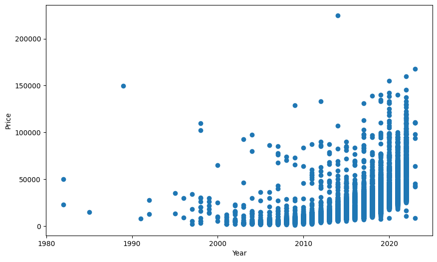

```python
# plot year - price
plt.figure(figsize=(10, 6))
plt.scatter(x=df["year"], y=df["price"])
plt.xlabel("Year")
plt.ylabel("Price")
plt.show()
```

```python
# create a LR model

## create a random test-train split
X = df[["year"]]
y = df["price"]
X_train, X_test, y_train, y_test = train_test_split(
    X, y, test_size=0.2, random_state=42
)

## variables
features = X.columns
numeric_features = ["year"]

## scale numeric features
scaler = StandardScaler()
X_train = scaler.fit_transform(X_train[numeric_features])
X_test = scaler.fit_transform(X_test[numeric_features])

## linear regression model
model = LinearRegression()
metrics, importances = evaluate_model(
    model,
    features,
    X_train,
    X_test,
    y_train,
    y_test,
    model_type="LR",
    model_variant="1",
    model_description="year",
)
```

```
Metric               Value
------------------------------
Model               : LR
Model-Desc          : LR1 - year
MAE                 : 10023.3740
MSE                 : 229771274.3893
MAPE                : 48.6496
R-squared           : 0.3558

Variable                                 Importance
--------------------------------------------------
year                                    : 10897.0582
```

Findings:

- low R-squared score, not explaining a significant proportion of the variance in `price`
- hard to know how other metrics score, as no other models to compare against
- `year` positively impacts `price` (the newer a vehicle is the more expensive the vehicle is)

```
Metric               Mean Value
------------------------------
MAE                 : 10483.879
MSE                 : 256421718.296
MAPE                : 50.969
R-squared           : 0.318
```

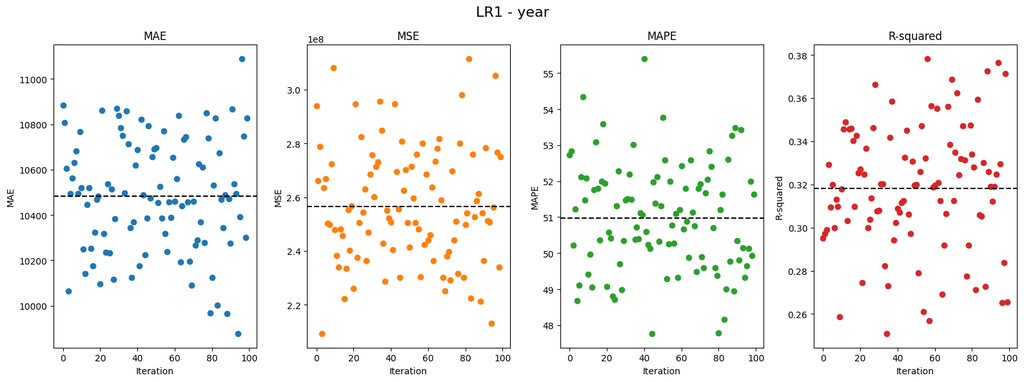

```python
# apply LR model over `n_sample` iterations

model_metrics = []

for i in tqdm(range(n_samples), desc="Model Iterations:"):
    ## create a random test-train split
    X = df[["year"]]
    y = df["price"]
    X_train, X_test, y_train, y_test = train_test_split(X, y, test_size=0.2)

    ## variables
    features = X.columns
    numeric_features = ["year"]

    ## scale numeric features
    scaler = StandardScaler()
    X_train = scaler.fit_transform(X_train[numeric_features])
    X_test = scaler.fit_transform(X_test[numeric_features])

    ## linear regression model
    model = LinearRegression()
    metrics, importances = evaluate_model(
        model,
        features,
        X_train,
        X_test,
        y_train,
        y_test,
        model_type="LR",
        model_variant="1",
        model_description="year",
        print_metrics=False,
        return_importance=False,
    )

    model_metrics.append(metrics)

## plot and generate average metrics
df_model_metrics = pd.DataFrame(model_metrics)
df_model = generate_plot(
    df_model_metrics, df_model_metrics["Model-Desc"].unique()[0], export_graph=True
)
df_metrics = pd.concat([df_metrics, df_model])
```

Findings:

- lots of variation between iterations, randomly splitting the model has an impact of model performance

#### Model2 - LR (year, mileage)

From the EDA analysis, `year` and `mileage` were the two variables with the largest magnitudes of correlation with the target variable (`price`), so we'll create a Linear Regression model using these two variables to predict price.

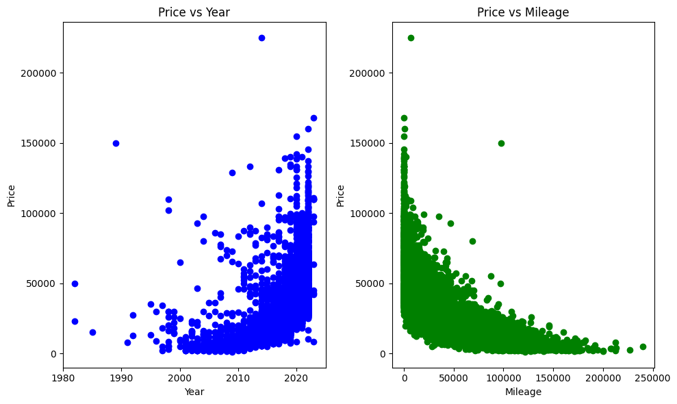

```python
# plot year - price and mileage - price
fig, axs = plt.subplots(1, 2, figsize=(10, 6))

# year - price
axs[0].scatter(df["year"], df["price"], color="blue")
axs[0].set_title("Price vs Year")
axs[0].set_xlabel("Year")
axs[0].set_ylabel("Price")

# mileage-price
axs[1].scatter(df["mileage"], df["price"], color="green")
axs[1].set_title("Price vs Mileage")
axs[1].set_xlabel("Mileage")
axs[1].set_ylabel("Price")

plt.tight_layout()
plt.show()
```

```python
# create a LR model

## create a random test-train split
X = df[["year", "mileage"]]
y = df["price"]
X_train, X_test, y_train, y_test = train_test_split(
    X, y, test_size=0.2, random_state=42
)

## variables
features = X.columns
numeric_features = ["year", "mileage"]

## scale numeric features
scaler = StandardScaler()
X_train = scaler.fit_transform(X_train[numeric_features])
X_test = scaler.fit_transform(X_test[numeric_features])

## linear regression model
model = LinearRegression()
metrics, importances = evaluate_model(
    model,
    features,
    X_train,
    X_test,
    y_train,
    y_test,
    model_type="LR",
    model_variant="2",
    model_description="year+mileage",
)
```

```
Metric               Value
------------------------------
Model               : LR
Model-Desc          : LR2 - year+mileage
MAE                 : 9462.9172
MSE                 : 190657306.1979
MAPE                : 48.2862
R-squared           : 0.4654

Variable                                 Importance
--------------------------------------------------
year                                    : 4058.6333
mileage                                 : -9878.6563
```

Findings:

- model performs better across all metrics, adding a second variable improves model performance
- `mileage` negatively impacts `price` (the more miles a vehicle has done, the cheaper the vehicle)

```
Metric               Mean Value
------------------------------
MAE                 : 9716.065
MSE                 : 207751001.029
MAPE                : 49.219
R-squared           : 0.448
```

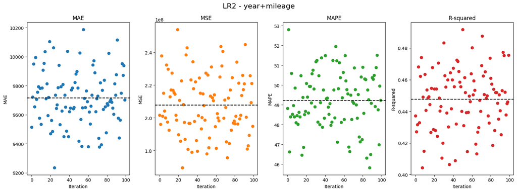

```python
# apply LR model over `n_sample` iterations

model_metrics = []

for i in tqdm(range(n_samples), desc="Model Iterations:"):
    ## create a random test-train split
    X = df[["year", "mileage"]]
    y = df["price"]
    X_train, X_test, y_train, y_test = train_test_split(X, y, test_size=0.2)

    ## variables
    features = X.columns
    numeric_features = ["year", "mileage"]

    ## scale numeric features
    scaler = StandardScaler()
    X_train = scaler.fit_transform(X_train[numeric_features])
    X_test = scaler.fit_transform(X_test[numeric_features])

    ## linear regression model
    model = LinearRegression()
    metrics, importances = evaluate_model(
        model,
        features,
        X_train,
        X_test,
        y_train,
        y_test,
        model_type="LR",
        model_variant="2",
        model_description="year+mileage",
        print_metrics=False,
        return_importance=False,
    )

    model_metrics.append(metrics)

## plot and generate average metrics
df_model_metrics = pd.DataFrame(model_metrics)
df_model = generate_plot(
    df_model_metrics, df_model_metrics["Model-Desc"].unique()[0], export_graph=True
)
df_metrics = pd.concat([df_metrics, df_model])
```

Findings:

- high variability in model due to random splitting of data still exists
- lower MAE, MSE and MAPE, but still very high - on average there is a 50% error in predictions (MAPE)
- low R-squared score, captures more data variance than previous model but still a low value

#### Model3 - LR (all numerical with correlation greater than 0.2)

From the EDA analysis, we can extract all numerical variables with a magnitude of correlation with the target variable (`price`) greater than 0.2 (arbitary value to select a range of features, but not all)

- `engine_size` : 0.23
- `year` : 0.64
- `mileage` : -0.65
- `feature_4` : 0.28
- `feature_5` : 0.37
- `feature_6` : -0.32

```
Metric               Mean Value
------------------------------
MAE                 : 8408.210
MSE                 : 167992106.840
MAPE                : 44.763
R-squared           : 0.549
```

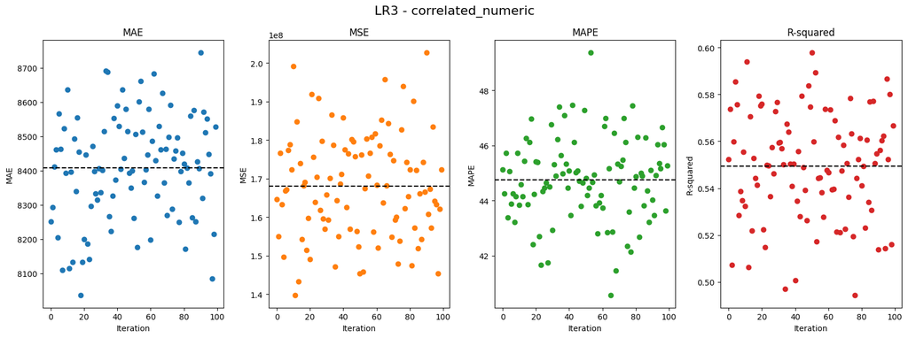

```python
# apply LR model over `n_sample` iterations

model_metrics = []

for i in tqdm(range(n_samples), desc="Model Iterations:"):
    ## create a random test-train split
    X = df[["engine_size", "year", "mileage", "feature_4", "feature_5", "feature_6"]]
    y = df["price"]
    X_train, X_test, y_train, y_test = train_test_split(X, y, test_size=0.2)

    ## variables
    features = X.columns
    numeric_features = ["engine_size", "year", "mileage"]

    ## scale numeric features
    scaler = StandardScaler()
    X_train = scaler.fit_transform(X_train[numeric_features])
    X_test = scaler.fit_transform(X_test[numeric_features])

    ## linear regression model
    model = LinearRegression()
    metrics, importances = evaluate_model(
        model,
        features,
        X_train,
        X_test,
        y_train,
        y_test,
        model_type="LR",
        model_variant="3",
        model_description="correlated_numeric",
        print_metrics=False,
        return_importance=False,
    )

    model_metrics.append(metrics)

## plot and generate average metrics
df_model_metrics = pd.DataFrame(model_metrics)
df_model = generate_plot(
    df_model_metrics, df_model_metrics["Model-Desc"].unique()[0], export_graph=True
)
df_metrics = pd.concat([df_metrics, df_model])
```

#### Model4 - LR (all numerical variables)

- no computational constraints, use all numerical variables

```
Metric               Mean Value
------------------------------
MAE                 : 8425.470
MSE                 : 168237511.848
MAPE                : 44.623
R-squared           : 0.552
```

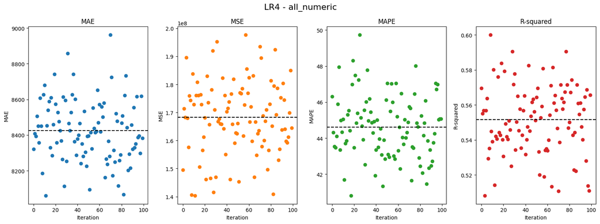

```python
# apply LR model over `n_sample` iterations

model_metrics = []

for i in tqdm(range(n_samples), desc="Model Iterations:"):
    ## create a random test-train split
    X = df[
        [
            "engine_size",
            "year",
            "mileage",
            "feature_1",
            "feature_2",
            "feature_3",
            "feature_4",
            "feature_5",
            "feature_6",
            "feature_7",
            "feature_8",
            "feature_9",
            "feature_10",
        ]
    ]
    y = df["price"]
    X_train, X_test, y_train, y_test = train_test_split(X, y, test_size=0.2)

    ## variables
    features = X.columns
    numeric_features = ["engine_size", "year", "mileage"]

    ## scale numeric features
    scaler = StandardScaler()
    X_train = scaler.fit_transform(X_train[numeric_features])
    X_test = scaler.fit_transform(X_test[numeric_features])

    ## linear regression model
    model = LinearRegression()
    metrics, importances = evaluate_model(
        model,
        features,
        X_train,
        X_test,
        y_train,
        y_test,
        model_type="LR",
        model_variant="4",
        model_description="all_numeric",
        print_metrics=False,
        return_importance=False,
    )

    model_metrics.append(metrics)

## plot and generate average metrics
df_model_metrics = pd.DataFrame(model_metrics)
df_model = generate_plot(
    df_model_metrics, df_model_metrics["Model-Desc"].unique()[0], export_graph=True
)
df_metrics = pd.concat([df_metrics, df_model])
```

#### Model5 - LR (all variables - categorical variables mixed encoded)

From the EDA, we know all vehicles are the same `make` so this can be dropped from the dataset. Meanwhile, we know each categorical variables has a set of unique category values:

- `model` has 58 variants
- `body_type` has 8 variants
- `fuel_type` has 7 variants
- `transmission` has 3 variants
- `colour` has 15 variants
- `area` has 115 variants

To handle these categorical values, a mixed encoding technique will be applied:

- use one-hot encoding for low variant (low cardinality) variables (`body_type`, `fuel_type`, `transmission`)
- use target encoding for high-cardinality columns :- replaces each category with a statistic (e.g., mean, median) of the target variable (price) within that category

##### ^^^ Mixed Encoding ^^^

```python
# apply mixed encoding technique

df_ = df.drop(["make"], axis=1)

## define column encoding
onehot_encode_columns = ["body_type", "fuel_type", "transmission"]
target_encode_columns = ["model", "colour", "area"]

## one-hot encode
df_encoded_mixed = pd.get_dummies(df_, columns=onehot_encode_columns)
## convert one-hot encoded columns to binary (1/0)
for col in df_encoded_mixed.columns:
    for colx in onehot_encode_columns:
        if colx in col:
            df_encoded_mixed[col] = df_encoded_mixed[col].astype(int)

## target encode
target_encoder = ce.TargetEncoder(cols=target_encode_columns)
df_encoded_mixed = target_encoder.fit_transform(
    df_encoded_mixed, df_encoded_mixed["price"]
)

## dimensions
print(df_encoded_mixed.shape)
df_encoded_mixed.head()
```

```
(9522, 35)
```

|  | model | engine_size | year | mileage | price | colour | area | feature_1 | feature_2 | feature_3 | feature_4 | feature_5 | feature_6 | feature_7 | feature_8 | feature_9 | feature_10 | body_type_Convertible | body_type_Coupe | body_type_Estate | body_type_Hatchback | body_type_MPV | body_type_SUV | body_type_Saloon | body_type_Unlisted | fuel_type_Diesel | fuel_type_Diesel Hybrid | fuel_type_Electric | fuel_type_Petrol | … |
| --- | --- | --- | --- | --- | --- | --- | --- | --- | --- | --- | --- | --- | --- | --- | --- | --- | --- | --- | --- | --- | --- | --- | --- | --- | --- | --- | --- | --- | --- | --- |
| 0 | 18746.713333 | 2.0 | 2021.0 | 13434 | 32000 | 26772.428191 | 20058.989169 | 1 | 1 | 1 | 0 | 1 | 1 | 0 | 1 | 1 | 1 | 0 | 0 | 0 | 0 | 0 | 1 | 0 | 0 | 0 | 0 | 0 | 1 | … |
| 1 | 33515.118361 | 1.5 | 2021.0 | 6347 | 32898 | 26772.428191 | 35618.577868 | 1 | 0 | 1 | 0 | 0 | 0 | 1 | 0 | 0 | 0 | 0 | 0 | 0 | 0 | 0 | 0 | 1 | 0 | 0 | 0 | 0 | 1 | … |
| 2 | 33515.118361 | 1.5 | 2021.0 | 10 | 35510 | 26772.428191 | 18750.370787 | 1 | 1 | 1 | 0 | 1 | 0 | 1 | 1 | 0 | 0 | 0 | 0 | 0 | 0 | 0 | 0 | 1 | 0 | 0 | 0 | 0 | 1 | … |
| 3 | 26799.032368 | 2.0 | 2022.0 | 6500 | 37999 | 30217.268641 | 25452.146019 | 1 | 1 | 1 | 0 | 1 | 1 | 1 | 0 | 0 | 0 | 0 | 1 | 0 | 0 | 0 | 0 | 0 | 0 | 0 | 1 | 0 | 0 | … |
| 4 | 16378.357724 | 2.0 | 2012.0 | 136952 | 4890 | 27543.439768 | 30553.387754 | 0 | 0 | 0 | 0 | 0 | 0 | 0 | 0 | 0 | 0 | 0 | 0 | 0 | 1 | 0 | 0 | 0 | 0 | 1 | 0 | 0 | 0 | … |

```
Metric               Mean Value
------------------------------
MAE                 : 5924.969
MSE                 : 82976780.084
MAPE                : 33.209
R-squared           : 0.778
```

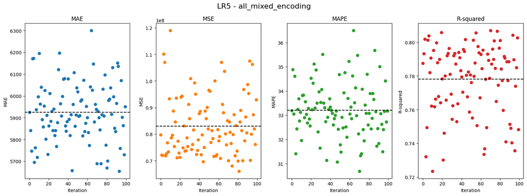

```python
# apply LR model over `n_sample` iterations

model_metrics = []

for i in tqdm(range(n_samples), desc="Model Iterations:"):
    ## create a random test-train split
    X = df_encoded_mixed.drop(columns=["price"], axis=1)
    y = df["price"]
    X_train, X_test, y_train, y_test = train_test_split(X, y, test_size=0.2)

    ## variables
    features = X.columns
    numeric_features = ["model", "engine_size", "year", "mileage", "colour", "area"]

    ## scale numeric features
    scaler = StandardScaler()
    X_train = scaler.fit_transform(X_train[numeric_features])
    X_test = scaler.fit_transform(X_test[numeric_features])

    ## linear regression model
    model = LinearRegression()
    metrics, importances = evaluate_model(
        model,
        features,
        X_train,
        X_test,
        y_train,
        y_test,
        model_type="LR",
        model_variant="5",
        model_description="all_mixed_encoding",
        print_metrics=False,
        return_importance=False,
    )

    model_metrics.append(metrics)

## plot and generate average metrics
df_model_metrics = pd.DataFrame(model_metrics)
df_model = generate_plot(
    df_model_metrics, df_model_metrics["Model-Desc"].unique()[0], export_graph=True
)
df_metrics = pd.concat([df_metrics, df_model])
```

#### Model6 - LR (all variables - categorical variables target encoded)

Similar to Model5, but instead of applying mixed encoding, target encoding is applied to all categorical columns

##### ^^^ Target Encoding ^^^

```python
# apply target encoding
df_ = df.drop(["make"], axis=1)

## define column encoding
target_encode_columns = [
    "model",
    "colour",
    "area",
    "body_type",
    "fuel_type",
    "transmission",
]

## target encode
target_encoder = ce.TargetEncoder(cols=target_encode_columns)
df_encoded_target = target_encoder.fit_transform(df_, df_["price"])

## dimensions
print(df_encoded_target.shape)
df_encoded_target.head()
```

```
(9522, 20)
```

|  | model | body_type | fuel_type | engine_size | transmission | year | mileage | price | colour | area | feature_1 | feature_2 | feature_3 | feature_4 | feature_5 | feature_6 | feature_7 | feature_8 | feature_9 | feature_10 |
| --- | --- | --- | --- | --- | --- | --- | --- | --- | --- | --- | --- | --- | --- | --- | --- | --- | --- | --- | --- | --- |
| 0 | 18746.713333 | 36917.730867 | 30126.084090 | 2.0 | 29911.183113 | 2021.0 | 13434 | 32000 | 26772.428191 | 20058.989169 | 1 | 1 | 1 | 0 | 1 | 1 | 0 | 1 | 1 | 1 |
| 1 | 33515.118361 | 25780.601498 | 30126.084090 | 1.5 | 29911.183113 | 2021.0 | 6347 | 32898 | 26772.428191 | 35618.577868 | 1 | 0 | 1 | 0 | 0 | 0 | 1 | 0 | 0 | 0 |
| 2 | 33515.118361 | 25780.601498 | 30126.084090 | 1.5 | 12759.030033 | 2021.0 | 10 | 35510 | 26772.428191 | 18750.370787 | 1 | 1 | 1 | 0 | 1 | 0 | 1 | 1 | 0 | 0 |
| 3 | 26799.032368 | 28897.715441 | 48817.767318 | 2.0 | 29911.183113 | 2022.0 | 6500 | 37999 | 30217.268641 | 25452.146019 | 1 | 1 | 1 | 0 | 1 | 1 | 1 | 0 | 0 | 0 |
| 4 | 16378.357724 | 19558.041931 | 17878.120375 | 2.0 | 12759.030033 | 2012.0 | 136952 | 4890 | 27543.439768 | 30553.387754 | 0 | 0 | 0 | 0 | 0 | 0 | 0 | 0 | 0 | 0 |

```
Metric               Mean Value
------------------------------
MAE                 : 5576.186
MSE                 : 79169223.187
MAPE                : 30.706
R-squared           : 0.789
```

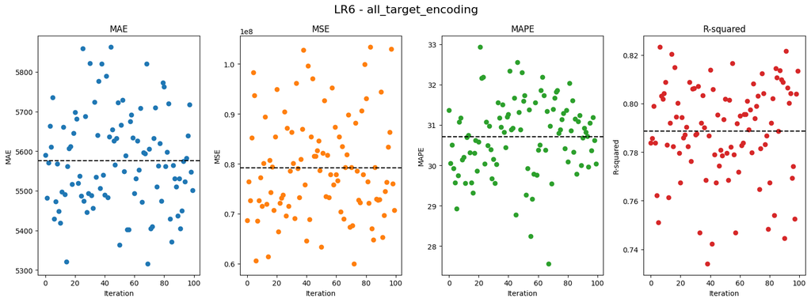

```python
# apply LR model over `n_sample` iterations

model_metrics = []

for i in tqdm(range(n_samples), desc="Model Iterations:"):
    ## create a random test-train split
    X = df_encoded_target.drop(columns=["price"], axis=1)
    y = df["price"]
    X_train, X_test, y_train, y_test = train_test_split(X, y, test_size=0.2)

    ## variables
    features = X.columns
    numeric_features = [
        "model",
        "engine_size",
        "year",
        "mileage",
        "colour",
        "area",
        "body_type",
        "fuel_type",
        "transmission",
    ]

    ## scale numeric features
    scaler = StandardScaler()
    X_train = scaler.fit_transform(X_train[numeric_features])
    X_test = scaler.fit_transform(X_test[numeric_features])

    ## linear regression model
    model = LinearRegression()
    metrics, importances = evaluate_model(
        model,
        features,
        X_train,
        X_test,
        y_train,
        y_test,
        model_type="LR",
        model_variant="6",
        model_description="all_target_encoding",
        print_metrics=False,
        return_importance=False,
    )

    model_metrics.append(metrics)

## plot and generate average metrics
df_model_metrics = pd.DataFrame(model_metrics)
df_model = generate_plot(
    df_model_metrics, df_model_metrics["Model-Desc"].unique()[0], export_graph=True
)
df_metrics = pd.concat([df_metrics, df_model])
```

### Gradient Boosting (GB)

From `LR` modelling, `Model5` (mixed encoding) and `Model6` (target encoding) perform best - only the data from these models will be used in `GB` modelling

#### Model5 – GB (all variables - categorical variables mixed encoded)

```
Metric               Mean Value
------------------------------
MAE                 : 3301.139
MSE                 : 36873167.192
MAPE                : 14.102
R-squared           : 0.902
```

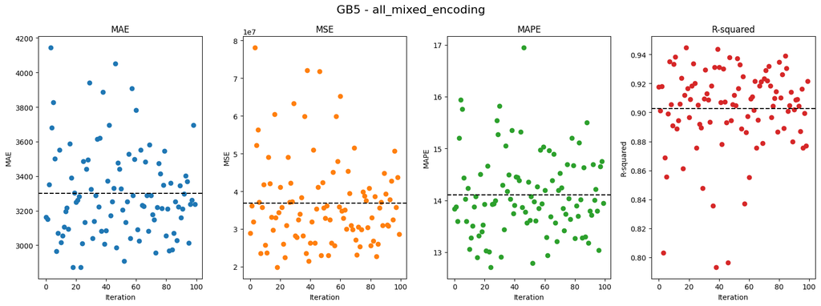

```python
# apply GB model over `n_sample` iterations

model_metrics = []

for i in tqdm(range(n_samples), desc="Model Iterations:"):
    ## create a random test-train split
    X = df_encoded_mixed.drop(columns=["price"], axis=1)
    y = df_encoded_mixed["price"]
    X_train, X_test, y_train, y_test = train_test_split(X, y, test_size=0.2)

    ## variables
    features = X.columns
    numeric_features = ["model", "engine_size", "year", "mileage", "colour", "area"]

    ## scale numeric features
    scaler = StandardScaler()
    X_train = scaler.fit_transform(X_train[numeric_features])
    X_test = scaler.fit_transform(X_test[numeric_features])

    ## gradient boosting model
    model = GradientBoostingRegressor()
    metrics, importances = evaluate_model(
        model,
        features,
        X_train,
        X_test,
        y_train,
        y_test,
        model_type="GB",
        model_variant="5",
        model_description="all_mixed_encoding",
        print_metrics=False,
        return_importance=False,
    )

    model_metrics.append(metrics)

## plot and generate average metrics
df_model_metrics = pd.DataFrame(model_metrics)
df_model = generate_plot(
    df_model_metrics, df_model_metrics["Model-Desc"].unique()[0], export_graph=True
)
df_metrics = pd.concat([df_metrics, df_model])
```

#### Model6 - GB (all variables - categorical variables target encoded)

```
Metric               Mean Value
------------------------------
MAE                 : 3291.519
MSE                 : 39159106.891
MAPE                : 14.202
R-squared           : 0.895
```

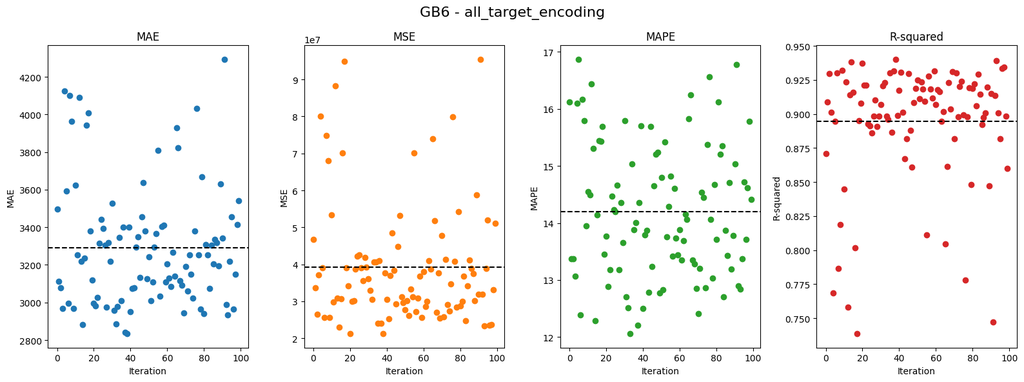

```python
# apply GB model over `n_sample` iterations

model_metrics = []

for i in tqdm(range(n_samples), desc="Model Iterations:"):
    ## create a random test-train split
    X = df_encoded_target.drop(columns=["price"], axis=1)
    y = df_encoded_target["price"]
    X_train, X_test, y_train, y_test = train_test_split(X, y, test_size=0.2)

    ## variables
    features = X.columns
    numeric_features = [
        "model",
        "engine_size",
        "year",
        "mileage",
        "colour",
        "area",
        "body_type",
        "fuel_type",
        "transmission",
    ]

    ## scale numeric features
    scaler = StandardScaler()
    X_train = scaler.fit_transform(X_train[numeric_features])
    X_test = scaler.fit_transform(X_test[numeric_features])

    ## gradient boosting model
    model = GradientBoostingRegressor()
    metrics, importances = evaluate_model(
        model,
        features,
        X_train,
        X_test,
        y_train,
        y_test,
        model_type="GB",
        model_variant="6",
        model_description="all_target_encoding",
        print_metrics=False,
        return_importance=False,
    )

    model_metrics.append(metrics)

## plot and generate average metrics
df_model_metrics = pd.DataFrame(model_metrics)
df_model = generate_plot(
    df_model_metrics, df_model_metrics["Model-Desc"].unique()[0], export_graph=True
)
df_metrics = pd.concat([df_metrics, df_model])
```

### Random Forest (RF)

From `LR` modelling, `Model5` (mixed encoding) and `Model6` (target encoding) perform best - only the data from these models will be used in `RF` modelling

#### Model5 - RF (all variables - categorical variables mixed encoded)

```
Metric               Mean Value
------------------------------
MAE                 : 2278.942
MSE                 : 22627944.690
MAPE                : 9.785
R-squared           : 0.940
```

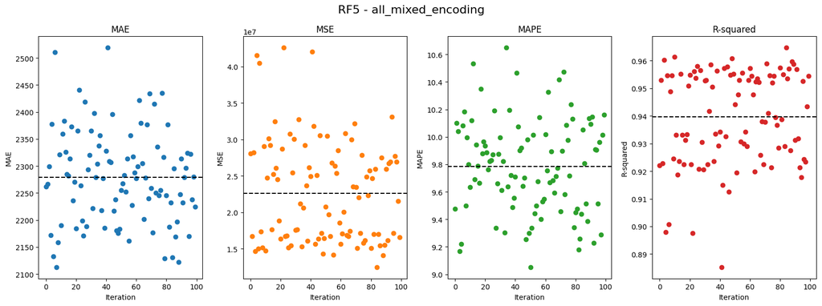

```python
# apply RF model over `n_sample` iterations

model_metrics = []

for i in tqdm(range(n_samples), desc="Model Iterations:"):
    ## create a random test-train split
    X = df_encoded_mixed.drop(columns=["price"], axis=1)
    y = df_encoded_mixed["price"]
    X_train, X_test, y_train, y_test = train_test_split(X, y, test_size=0.2)

    ## variables
    features = X.columns
    numeric_features = ["model", "engine_size", "year", "mileage", "colour", "area"]

    ## random forest model
    model = RandomForestRegressor()
    metrics, importances = evaluate_model(
        model,
        features,
        X_train,
        X_test,
        y_train,
        y_test,
        model_type="RF",
        model_variant="5",
        model_description="all_mixed_encoding",
        print_metrics=False,
        return_importance=False,
    )

    model_metrics.append(metrics)

## plot and generate average metrics
df_model_metrics = pd.DataFrame(model_metrics)
df_model = generate_plot(
    df_model_metrics, df_model_metrics["Model-Desc"].unique()[0], export_graph=True
)
df_metrics = pd.concat([df_metrics, df_model])
```

#### Model6 - RF (all variables - categorical variables target encoded)

```
Metric               Mean Value
------------------------------
MAE                 : 2296.675
MSE                 : 22542655.600
MAPE                : 9.919
R-squared           : 0.940
```

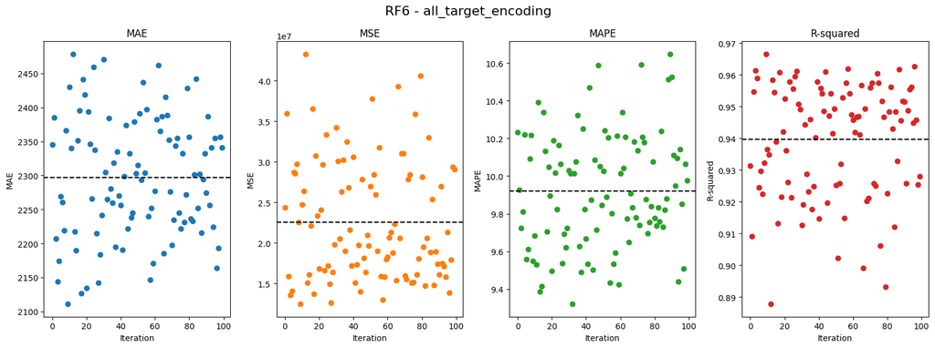

```python
# apply RF model over `n_sample` iterations

model_metrics = []

for i in tqdm(range(n_samples), desc="Model Iterations:"):
    ## create a random test-train split
    X = df_encoded_target.drop(columns=["price"], axis=1)
    y = df_encoded_mixed["price"]
    X_train, X_test, y_train, y_test = train_test_split(X, y, test_size=0.2)

    ## variables
    features = X.columns
    numeric_features = [
        "model",
        "engine_size",
        "year",
        "mileage",
        "colour",
        "area",
        "body_type",
        "fuel_type",
        "transmission",
    ]

    ## random forest model
    model = RandomForestRegressor()
    metrics, importances = evaluate_model(
        model,
        features,
        X_train,
        X_test,
        y_train,
        y_test,
        model_type="RF",
        model_variant="6",
        model_description="all_target_encoding",
        print_metrics=False,
        return_importance=False,
    )

    model_metrics.append(metrics)

## plot and generate average metrics
df_model_metrics = pd.DataFrame(model_metrics)
df_model = generate_plot(
    df_model_metrics, df_model_metrics["Model-Desc"].unique()[0], export_graph=True
)
df_metrics = pd.concat([df_metrics, df_model])
```

# Evaluate

Evaluate the model variants by comparing performance metrics from the `n_sample` itertaions per model.

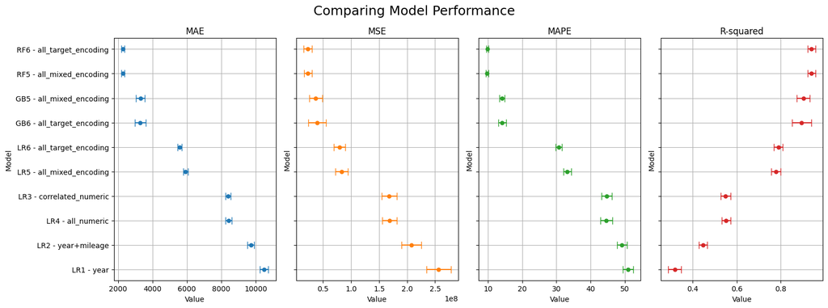

```python
def plot_metrics_with_error_bars(df):
    # Pivot the dataframe to get mean and std for each metric
    pivot_df = df.pivot(
        index="Model", columns="Metric", values=["Mean", "Std"]
    ).reset_index()
    pivot_df.columns = [" ".join(col).strip() for col in pivot_df.columns]
    pivot_df = pivot_df.sort_values(["Mean MSE"], ascending=False)

    # Define the metrics to plot
    metrics = ["MAE", "MSE", "MAPE", "R-squared"]

    # Set up the subplot layout
    fig, axes = plt.subplots(1, len(metrics), figsize=(16, 6), sharey=True)

    # Plot each metric
    for i, (ax, metric) in enumerate(zip(axes, metrics)):
        ax.errorbar(
            pivot_df[f"Mean {metric}"],
            pivot_df["Model"],
            xerr=pivot_df[f"Std {metric}"],
            fmt="o",
            label=metric,
            markersize=5,
            capsize=5,
            color=sns.color_palette()[i],
        )
        ax.set_title(metric)
        ax.set_ylabel("Model")  # Y-axis label as 'Model'
        ax.set_xlabel("Value")  # X-axis label as 'Value'
        ax.grid(True)

    plt.suptitle("Comparing Model Performance", size=18)
    plt.tight_layout()
    file_name = "model_" + "metric_comparison" + ".png"
    plt.savefig("/".join([directory_path, file_path, file_name]))
    plt.show()


plot_metrics_with_error_bars(df_metrics)
```

Findings:

# Investigate

```python
# create a RF model (for investigations)

# create a random test-train split
X = df_encoded_target.drop(columns=["price"], axis=1)
y = df_encoded_target["price"]
X_train, X_test, y_train, y_test = train_test_split(X, y, test_size=0.2)

# variables
features = X.columns
numeric_features = [
    "model",
    "engine_size",
    "year",
    "mileage",
    "colour",
    "area",
    "body_type",
    "fuel_type",
    "transmission",
]

# Random Forest model
output_model = RandomForestRegressor()
metrics, importances = evaluate_model(
    output_model,
    features,
    X_train,
    X_test,
    y_train,
    y_test,
    model_type="RF",
    model_variant="6",
    model_description="all_target_encoding",
    print_metrics=False,
    return_importance=True,
)
```

```
Variable                                 Importance
--------------------------------------------------
model                                   : 0.2900
body_type                               : 0.0079
fuel_type                               : 0.0051
engine_size                             : 0.0513
transmission                            : 0.0070
year                                    : 0.1382
mileage                                 : 0.4741
colour                                  : 0.0068
area                                    : 0.0072
feature_1                               : 0.0008
feature_2                               : 0.0013
feature_3                               : 0.0014
feature_4                               : 0.0020
feature_5                               : 0.0011
feature_6                               : 0.0010
feature_7                               : 0.0009
feature_8                               : 0.0003
feature_9                               : 0.0027
feature_10                              : 0.0009
```

## Feature Importance

- explore variable feature importance from single model iteration

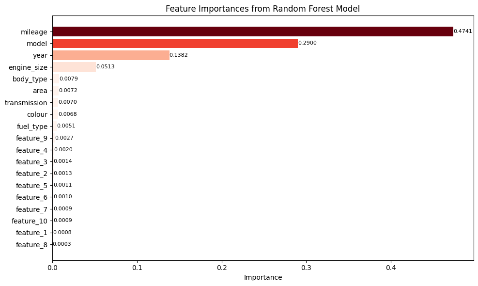

```python
# perform feature importance analysis

## sort the DataFrame by importance
importance_df = pd.DataFrame(importances).sort_values(by="Importance", ascending=False)

## normalise feature importance scores to get values between 0 and 1 and create a colour map
importance_values = np.array(list(importance_df["Importance"]))
normed_scores = (importance_values - importance_values.min()) / (
    importance_values.max() - importance_values.min()
)
colors = plt.cm.Reds(normed_scores)

## plotting feature importances
plt.figure(figsize=(10, 6))
bars = plt.barh(importance_df["Variable"], importance_df["Importance"], color=colors)
## add value annotations
for bar in bars:
    plt.text(
        bar.get_width(),
        bar.get_y() + bar.get_height() / 2,
        f"{bar.get_width():.4f}",
        va="center",
        ha="left",
        size=8,
    )
plt.xlabel("Importance")
plt.title("Feature Importances from Random Forest Model")
plt.gca().invert_yaxis()  # invert y-axis to have the most important feature on top
plt.tight_layout()
file_name = "model_" + "rf6_feature_importance" + ".png"
plt.savefig("/".join([directory_path, file_path, file_name]))
plt.show()
```

Findings:

- features with low importance (< 0.01) could be dropped before hyperparameter tuning, or, if computational resources are limited
- in this case, the model build time is not too long, therefore we can retain all features, even if they only add partial information!
- `mileage`, `model`, `'year`, `engine_size` have a significant feature importance and thus have strong predicitve power
- the `feature_x` variables have very small feature importance, and could be candidates for dropping/removal from the modelling

## Permutations Analysis

-in order to evaluate the impact of the `feature_x` columns on model performance, we can make permutations in `feature_` columns and revaluate model performance metrics and compare against the orignal model (i.e. column by column, change `feature_` values and examine the impact on performance when predicting price)

```python
# perform permutations analysis

## specify the columns to permute (e.g., columns named feature_1 to feature_10)
columns_to_permute = [col for col in X_test.columns if "feature_" in col]

permuted_mse_list = []
## run the permutation process over n_samples
for i in range(n_samples):
    X_test_permuted = X_test.copy()

    ## iterate through columns for each sample iteration
    for col in columns_to_permute:
        X_test_permuted[col] = np.random.permutation(X_test_permuted[col].values)

        ## evaluate the model after permutation
        y_pred_permuted = output_model.predict(X_test_permuted)
        permuted_mse = mean_squared_error(y_test, y_pred_permuted)

        ## store the permuted MSE in the list
        permuted_mse_list.append({"feature": col, "mse": permuted_mse})

        ##  reset
        X_test_permuted = X_test.copy()

df_permuted_mse = pd.DataFrame(permuted_mse_list)

## conduct analysis of iterations
df_permuted_mse_totals = (
    df_permuted_mse.groupby(["feature"])
    .agg(mean_mse=("mse", "mean"), std_mse=("mse", "sum"))
    .reset_index()
)
## calculate delta from original model
df_permuted_mse_totals["delta"] = abs(
    df_permuted_mse_totals["mean_mse"] - metrics["MSE"]
)
df_permuted_mse_totals["delta_percentage"] = (
    100 * df_permuted_mse_totals["delta"] / metrics["MSE"]
)
df_permuted_mse_totals.sort_values(["delta_percentage"], ascending=False)
```

|  | feature | mean_mse | std_mse | delta | delta_percentage |
| --- | --- | --- | --- | --- | --- |
| 9 | feature_9 | 1.749176e+07 | 1.749176e+09 | 982874.103110 | 5.953606 |
| 4 | feature_4 | 1.711802e+07 | 1.711802e+09 | 609136.176910 | 3.689747 |
| 2 | feature_2 | 1.701139e+07 | 1.701139e+09 | 502503.133806 | 3.043834 |
| 7 | feature_7 | 1.676677e+07 | 1.676677e+09 | 257879.604191 | 1.562065 |
| 3 | feature_3 | 1.673127e+07 | 1.673127e+09 | 222385.949793 | 1.347068 |
| 1 | feature_10 | 1.662066e+07 | 1.662066e+09 | 111767.158085 | 0.677012 |
| 0 | feature_1 | 1.655836e+07 | 1.655836e+09 | 49468.225215 | 0.299646 |
| 6 | feature_6 | 1.655040e+07 | 1.655040e+09 | 41508.218125 | 0.251430 |
| 5 | feature_5 | 1.653552e+07 | 1.653552e+09 | 26635.543081 | 0.161341 |
| 8 | feature_8 | 1.649571e+07 | 1.649571e+09 | 13176.880534 | 0.079817 |

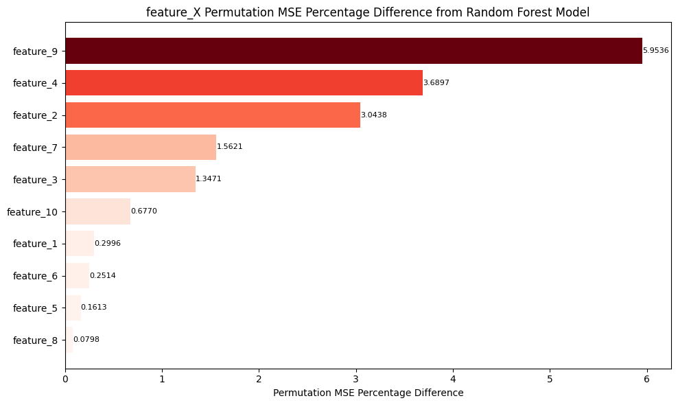

```python
# plot permutations importance (delta percentage)

## sort the DataFrame by delta_percentage
importance_df = df_permuted_mse_totals.sort_values(
    by="delta_percentage", ascending=False
)

## normalise feature importance scores to get values between 0 and 1 and create colour map
importance_values = np.array(list(importance_df["delta_percentage"]))
normed_scores = (importance_values - importance_values.min()) / (
    importance_values.max() - importance_values.min()
)
colors = plt.cm.Reds(normed_scores)

## plotting feature importances
plt.figure(figsize=(10, 6))
bars = plt.barh(
    importance_df["feature"], importance_df["delta_percentage"], color=colors
)
## add value annotations
for bar in bars:
    plt.text(
        bar.get_width(),
        bar.get_y() + bar.get_height() / 2,
        f"{bar.get_width():.4f}",
        va="center",
        ha="left",
        size=8,
    )
plt.xlabel("Permutation MSE Percentage Difference")
plt.title("feature_X Permutation MSE Percentage Difference from Random Forest Model")
plt.gca().invert_yaxis()  # invert y-axis to have the most important feature on top
plt.tight_layout()
file_name = "model_" + "rf6_permutation_importance" + ".png"
plt.savefig("/".join([directory_path, file_path, file_name]))
plt.show()
```

Findings:

## Price Position Dimension

- compare the prediction residuals of the selected model with `price_position` to understand any relationship and infer what the `price_position` variable describes

```python
# use the `output_model`, generate predictions, calculate residuals

## fit model
output_model.fit(X_train, y_train)

## make predictions
y_pred = output_model.predict(X_test)

## get `price_position` by joining y_test with raw data
df_comp = pd.DataFrame(y_test).merge(
    df_in["price_position"], left_index=True, right_index=True
)
df_comp["price_pred"] = y_pred

## calcuate residuals
df_comp["residuals"] = df_comp["price"] - df_comp["price_pred"]
```

```python
# flag outliers using z-score

## drop NAs
df_graph = df_comp[["price_position", "residuals"]].dropna()

## get outlier per column
z_scores_x = np.abs(stats.zscore(df_graph["price_position"]))
df_graph["is_outlier_x"] = z_scores_x > 3

z_scores_y = np.abs(stats.zscore(df_graph["residuals"]))
df_graph["is_outlier_y"] = z_scores_y > 3

## create outlier flag
df_graph["is_outlier"] = np.where(
    df_graph["is_outlier_x"] | df_graph["is_outlier_y"], 1, 0
)
```

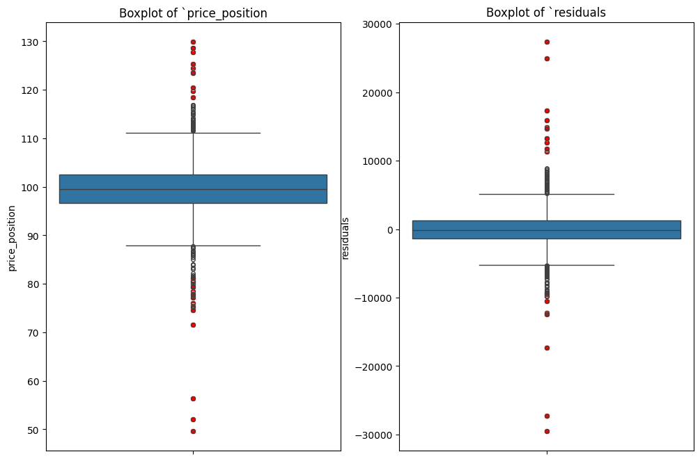

```python
# plot ## box and whisker to show distributions and flag outliers per variable

## plot
plt.figure(figsize=(12, 8))

## price position
plt.subplot(1, 2, 1)
n_outliers = df_graph.query("is_outlier_x==True").shape[0]
sns.boxplot(
    df_graph["price_position"], flierprops=dict(marker="o", color="red", markersize=4)
)
sns.scatterplot(
    x=[0] * n_outliers,
    y=df_graph.query("is_outlier_x==True")["price_position"],
    color="red",
)
plt.title("Boxplot of `price_position")

## residuals
plt.subplot(1, 2, 2)
n_outliers = df_graph.query("is_outlier_y==True").shape[0]
sns.boxplot(
    df_graph["residuals"], flierprops=dict(marker="o", color="red", markersize=4)
)
sns.scatterplot(
    x=[0] * n_outliers, y=df_graph.query("is_outlier_y==True")["residuals"], color="red"
)
plt.title("Boxplot of `residuals")

plt.show()
```

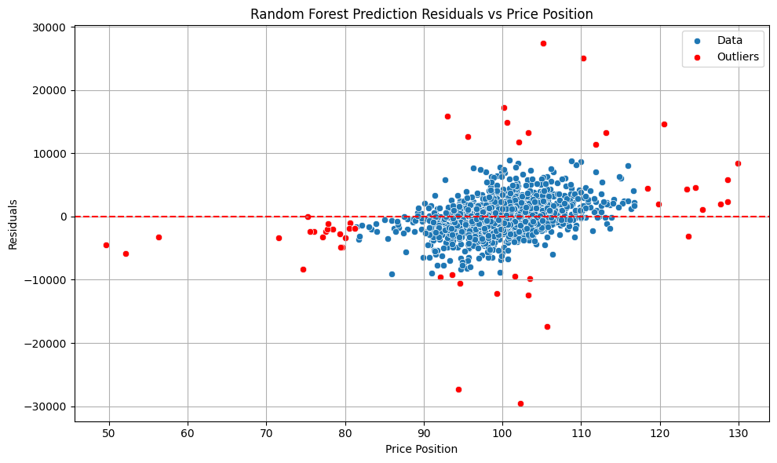

```
Correlation between residuals and price position                      : 0.35
Correlation between residuals and price position (ignoring outliers)  : 0.39
```

```python
# plot residuals vs price_position, flagging outliers, calculate correlations

## plot
plt.figure(figsize=(10, 6))
sns.scatterplot(data=df_graph, x="price_position", y="residuals", label="Data")
sns.scatterplot(
    x=df_graph.query("is_outlier==1")["price_position"],
    y=df_graph.query("is_outlier==1")["residuals"],
    color="red",
    label="Outliers",
)
plt.axhline(0, color="red", linestyle="--")
plt.title("Random Forest Prediction Residuals vs Price Position")
plt.xlabel("Price Position")
plt.ylabel("Residuals")
plt.grid()
plt.legend()
plt.tight_layout()
file_name = "model_" + "residuals_price_position" + ".png"
plt.savefig("/".join([directory_path, file_path, file_name]))
plt.show()

# correlations (with and without outliers)
correlation = df_graph["residuals"].corr(df_graph["price_position"])
print(f'{"Correlation between residuals and price position":<70}: {correlation:.2f}')
correlation = df_graph.query("is_outlier==0")["residuals"].corr(
    df_graph.query("is_outlier==0")["price_position"]
)
print(
    f'{"Correlation between residuals and price position (ignoring outliers)":<70}: {correlation:.2f}'
)
```

Findings:

Interpretation of Price Position:

- Price Position is likely a measure that compares a vehicle's price relative to others within the dataset or market. It may factor in variables like model, age, and mileage.
- Vehicles with a high price position are priced at a premium relative to others, while those with a low price position are priced more competitively or affordably.

```python
# examine some outliers
outlier_index = df_graph.query("is_outlier==1").head()

df_in.iloc[outlier_index.index]
```

[output not shown]

Findings:

- some outliers at the extremes of mileage (very low and very high)
- some outliers at the extremes of price (very low and very high)
- other outliers are potentially rare/premium cars with an outlier combination of price, mileage and other features

## Hyperparameter Tune

Tune the random forest models hyperparameters and cross-validation to determine whether an improved model configuration can be found. Important parameters to tune:

- n_estimators: number of trees in the forest - increasing the number of trees can improve performance, but it also increases computational cost and training time.
- max_features: number of features to consider when looking for the best split - lowering this can reduce overfitting, but too low a value may lead to underfitting
- maximum depth of each tree - limiting the depth of trees can prevent overfitting, a deeper tree can model more complex relationships but may lead to overfitting
- min_samples_split: minimum number of samples required to split an internal node - increasing this value can help prevent overfitting by requiring more samples to create a split
- min_samples_leaf: minimum number of samples required to be at a leaf node - can help prevent overfitting by ensuring that leaf nodes have a minimum number of samples
- bootstrap: whether bootstrap samples are used when building trees

```python
# current model parameters - default values
print("Parameters currently in use:\n")
pprint(output_model.get_params())
```

```
Parameters currently in use:

{'bootstrap': True,
 'ccp_alpha': 0.0,
 'criterion': 'squared_error',
 'max_depth': None,
 'max_features': 1.0,
 'max_leaf_nodes': None,
 'max_samples': None,
 'min_impurity_decrease': 0.0,
 'min_samples_leaf': 1,
 'min_samples_split': 2,
 'min_weight_fraction_leaf': 0.0,
 'monotonic_cst': None,
 'n_estimators': 100,
 'n_jobs': None,
 'oob_score': False,
 'random_state': None,
 'verbose': 0,
 'warm_start': False}
```

```python
# create random grid for hyperparameter tuning

## number of trees in random forest
n_estimators = [int(x) for x in np.linspace(start=200, stop=2000, num=10)]
## number of features to consider at every split
max_features = [None, "sqrt", "log2"]
## maximum number of levels in tree
max_depth = [int(x) for x in np.linspace(10, 110, num=11)]
max_depth.append(None)
## minimum number of samples required to split a node
min_samples_split = [2, 5, 10]
## minimum number of samples required at each leaf node
min_samples_leaf = [1, 2, 4]
## method of selecting samples for training each tree
bootstrap = [True]

## create the random grid
random_grid = {
    "n_estimators": n_estimators,
    "max_features": max_features,
    "max_depth": max_depth,
    "min_samples_split": min_samples_split,
    "min_samples_leaf": min_samples_leaf,
    "bootstrap": bootstrap,
}

pprint(random_grid)
```

```
{'bootstrap': [True],
 'max_depth': [10, 20, 30, 40, 50, 60, 70, 80, 90, 100, 110, None],
 'max_features': [None, 'sqrt', 'log2'],
 'min_samples_leaf': [1, 2, 4],
 'min_samples_split': [2, 5, 10],
 'n_estimators': [200, 400, 600, 800, 1000, 1200, 1400, 1600, 1800, 2000]}
```

```python
# search for best hyperparameters using random grid

## random search of parameters, using 3 fold cross validation, across 100 different combinations, and use all available cores
rf_random = RandomizedSearchCV(
    estimator=output_model,
    param_distributions=random_grid,
    n_iter=100,
    cv=3,
    verbose=2,
    random_state=42,
    n_jobs=-1,
)

## generate train-test sets, only use important features from previous analysis
X = df_encoded_target[["mileage", "model", "year", "engine_size"]]
y = df_encoded_target["price"]
X_train, X_test, y_train, y_test = train_test_split(X, y, test_size=0.2)

## fit the random search model
rf_random.fit(X_train, y_train)
```

[output not shown]

[output cut: 246 more lines]

[output not shown]

```
RandomizedSearchCV(cv=3, estimator=RandomForestRegressor(), n_iter=100,
                   n_jobs=-1,
                   param_distributions={'bootstrap': [True],
                                        'max_depth': [10, 20, 30, 40, 50, 60,
                                                      70, 80, 90, 100, 110,
                                                      None],
                                        'max_features': [None, 'sqrt', 'log2'],
                                        'min_samples_leaf': [1, 2, 4],
                                        'min_samples_split': [2, 5, 10],
                                        'n_estimators': [200, 400, 600, 800,
                                                         1000, 1200, 1400, 1600,
                                                         1800, 2000]},
                   random_state=42, verbose=2)
```

```python
# best parameters from random grid
print(rf_random.best_params_)
```

```
{'n_estimators': 1600, 'min_samples_split': 10, 'min_samples_leaf': 1, 'max_features': 'log2', 'max_depth': 40, 'bootstrap': True}
```

```
Metric               Mean Value
------------------------------
MAE                 : 2525.985
MSE                 : 23882682.171
MAPE                : 11.052
R-squared           : 0.936
```

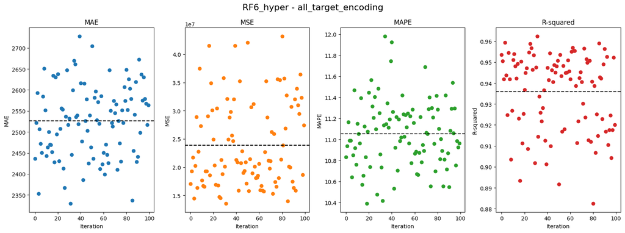

```python
# apply RF model over `n_sample` iterations

model_metrics = []

for i in tqdm(range(n_samples), desc="Model Iterations:"):
    ## create a random test-train split
    X = df_encoded_target[["mileage", "model", "year", "engine_size"]]
    y = df_encoded_mixed["price"]
    X_train, X_test, y_train, y_test = train_test_split(X, y, test_size=0.2)

    ## variables
    features = X.columns
    numeric_features = ["mileage", "model", "year", "engine_size"]

    ## random forest model with best hyperparameters
    model = rf_random.best_estimator_
    metrics, importances = evaluate_model(
        model,
        features,
        X_train,
        X_test,
        y_train,
        y_test,
        model_type="RF",
        model_variant="6_hyper",
        model_description="all_target_encoding",
        print_metrics=False,
        return_importance=False,
    )

    model_metrics.append(metrics)

## plot and generate average metrics
df_model_metrics = pd.DataFrame(model_metrics)
df_model = generate_plot(
    df_model_metrics, df_model_metrics["Model-Desc"].unique()[0], export_graph=True
)
df_metrics = pd.concat([df_metrics, df_model])
```

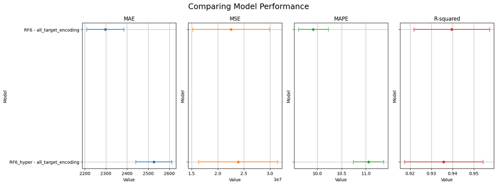

```python
def plot_metrics_with_error_bars(df):
    # Pivot the dataframe to get mean and std for each metric
    pivot_df = df.pivot(
        index="Model", columns="Metric", values=["Mean", "Std"]
    ).reset_index()
    pivot_df.columns = [" ".join(col).strip() for col in pivot_df.columns]
    pivot_df = pivot_df.sort_values(["Mean MSE"], ascending=False)

    # Define the metrics to plot
    metrics = ["MAE", "MSE", "MAPE", "R-squared"]

    # Set up the subplot layout
    fig, axes = plt.subplots(1, len(metrics), figsize=(16, 6), sharey=True)

    # Plot each metric
    for i, (ax, metric) in enumerate(zip(axes, metrics)):
        ax.errorbar(
            pivot_df[f"Mean {metric}"],
            pivot_df["Model"],
            xerr=pivot_df[f"Std {metric}"],
            fmt="o",
            label=metric,
            markersize=5,
            capsize=5,
            color=sns.color_palette()[i],
        )
        ax.set_title(metric)
        ax.set_ylabel("Model")  # Y-axis label as 'Model'
        ax.set_xlabel("Value")  # X-axis label as 'Value'
        ax.grid(True)

    plt.suptitle("Comparing Model Performance", size=18)
    plt.tight_layout()
    file_name = "model_" + "metric_comparison_hyperparameter" + ".png"
    plt.savefig("/".join([directory_path, file_path, file_name]))
    plt.show()


# RF6 models only
plot_metrics_with_error_bars(
    df_metrics[df_metrics["Model"].str.contains("RF6", na=False)]
)
```

Findings:

- tuning of hyperparamters has minimal impact on the model performance (on average, if anything slightly worse) - the default random forest is sufficent for analysis

# Next Steps / Improvements

- data quality: resolve data quality issues (either at source or using logic)
- alternative methods: neural networks, regression with regularsation, handling outliers (different models for extremes vs common vehicles), cross-validation
- tuning: explore hyperparameter tuning in more detail for Gradient Boosting methods
- productionisation: scalable infrastructure, containerise, create package
- testing: unit testing, data validations, A/B testing
- monitoring: data quaility, model performance, adoption